# 126 Project

Cynthia Shim, Jonathan Chen, Connor Wall

5/31/2020

```r
library(leaps)
library(car)
Concrete_Data <- read.csv("Concrete_data.csv")

Concrete_Data[Concrete_Data == 0] <- 0.0001

cement <- Concrete_Data$X540.0
slag <- Concrete_Data$X0.0
flyAsh <- Concrete_Data$X0.0.1
water <- Concrete_Data$X162.0
superplasticizer <- Concrete_Data$X2.5
coarseAggregate <- Concrete_Data$X1040.0
fineAggregate <- Concrete_Data$X676.0
age <- Concrete_Data$X28

strength <- Concrete_Data$X79.99
```

NOTE: We needed to replace instances of 0 with 0.0001 for powerTransform. Or else we would have recieved this error code: “Error in bc1(out[, j], lambda[j]) : First argument must be strictly positive.”

I started off my analysis by creating scatterplots.

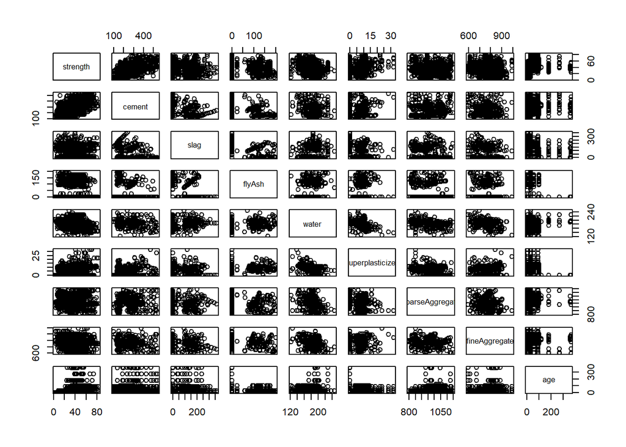

```r
pairs( ~ strength + cement + slag + flyAsh + water + superplasticizer + coarseAggregate + fineAggregate + age)
```

I can’t read this scatterplot, so I decided to run `pairs()` multiple times.

I’ve already decided that `strength` would be my response variable, due to it’s interest in our scientific study. So I’ve checked every scatterplot with `strength`.

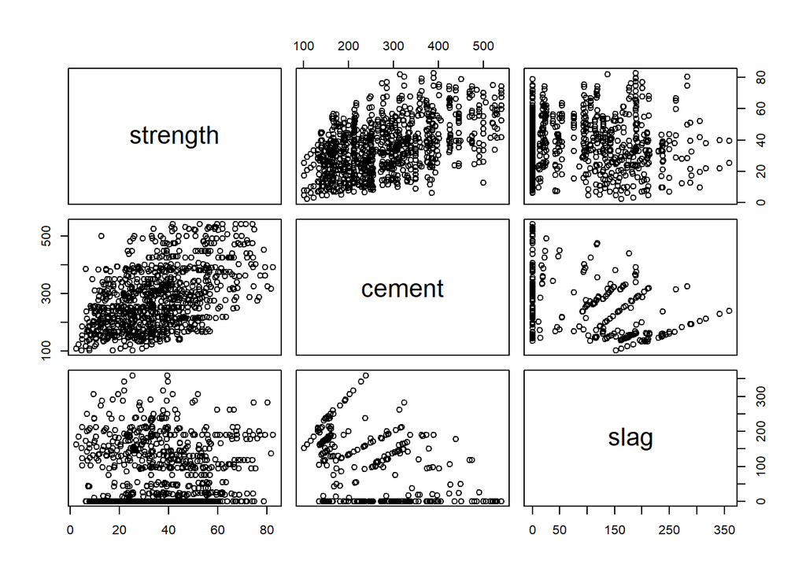

```r
pairs( ~ strength + cement + slag)
```

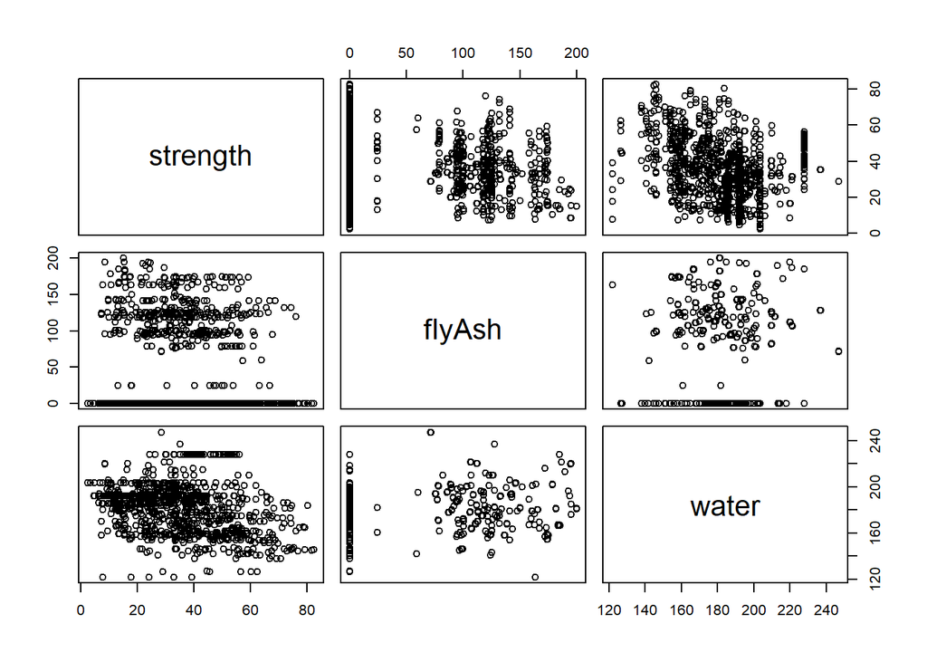

```r
pairs( ~ strength + flyAsh + water)
```

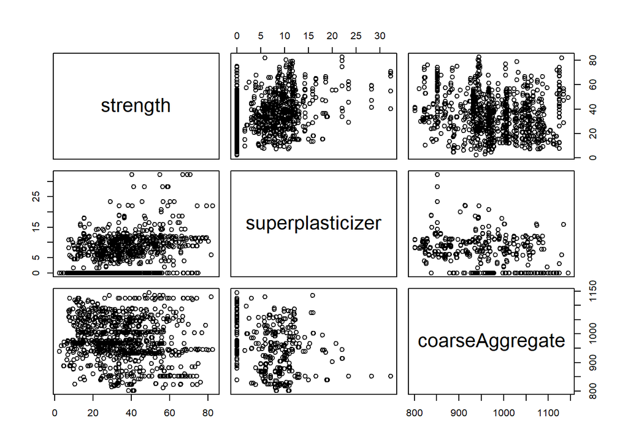

```r
pairs( ~ strength + superplasticizer + coarseAggregate)
```

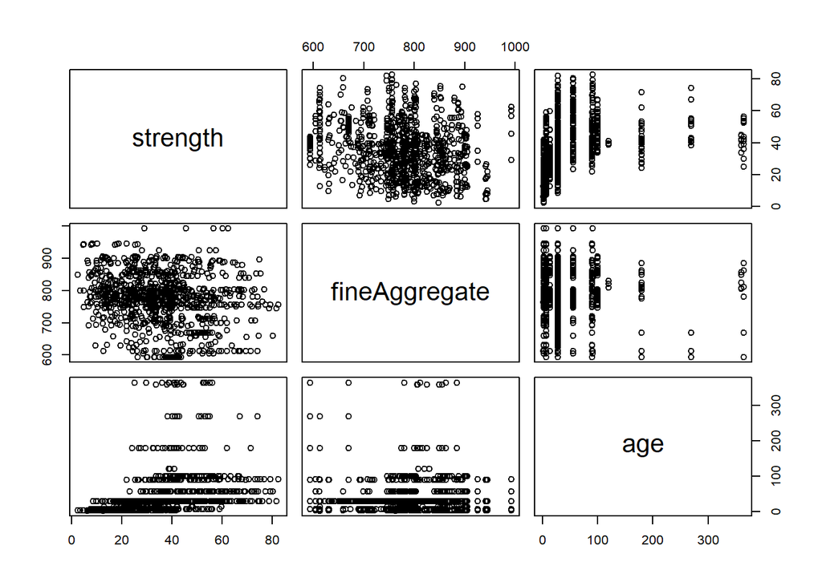

```r
pairs( ~ strength + fineAggregate + age)
```

I could only see a linear trend on `strength` with `age` and `cement`.

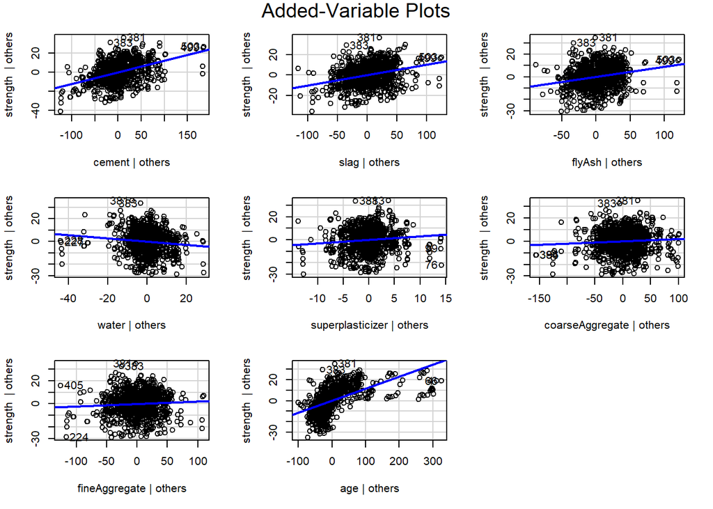

```r
mod.full <- lm(strength~ cement + slag + flyAsh + water + superplasticizer + coarseAggregate + fineAggregate + age)
avPlots(mod.full)
```

These avPlots indicate that `fineAggregates` and `coarseAggregates` don’t contain any additional useful information after considering the effect of the other predictors. The avPlots also support my previous claim that `age` and `cement` have strong relations with `strength`.

I’m suspicious that `fineAggregate` or `coarseAggregate` could have only become useless after considering each other. Maybe, without the other in consideration, one of these two could have been still been useful after considering the rest of the predictors. So I’ve conducted 2 Partial F Tests.

F test: F =
$$T^2$$
where T ~
$$T_{n-p-1}$$

```r
anova( lm(strength ~ cement + slag + flyAsh + water + superplasticizer + age + coarseAggregate) )
```

```
## Analysis of Variance Table
##
## Response: strength
##                    Df Sum Sq Mean Sq  F value    Pr(>F)
## cement              1  69779   69779 646.8691 < 2.2e-16 ***
## slag                1  23002   23002 213.2353 < 2.2e-16 ***
## flyAsh              1  21623   21623 200.4501 < 2.2e-16 ***
## water               1  11347   11347 105.1927 < 2.2e-16 ***
## superplasticizer    1   1479    1479  13.7136 0.0002243 ***
## age                 1  47812   47812 443.2302 < 2.2e-16 ***
## coarseAggregate     1     42      42   0.3878 0.5336163
## Residuals        1021 110137     108
## ---
## Signif. codes:  0 '***' 0.001 '**' 0.01 '*' 0.05 '.' 0.1 ' ' 1
```

$$H_0$$
: $\beta_7$ = 0 vs
$$H_A$$
: $\beta_7$ 0

So `coarseAggregate` is not a useful predictor, after controlling for the effects of all the other predictors (except for `fineAggregate`)

```r
anova( lm(strength ~ cement + slag + flyAsh + water + superplasticizer + age + fineAggregate) )
```

```
## Analysis of Variance Table
##
## Response: strength
##                    Df Sum Sq Mean Sq  F value    Pr(>F)
## cement              1  69779   69779 646.8575 < 2.2e-16 ***
## slag                1  23002   23002 213.2315 < 2.2e-16 ***
## flyAsh              1  21623   21623 200.4465 < 2.2e-16 ***
## water               1  11347   11347 105.1908 < 2.2e-16 ***
## superplasticizer    1   1479    1479  13.7133 0.0002243 ***
## age                 1  47812   47812 443.2222 < 2.2e-16 ***
## fineAggregate       1     40      40   0.3694 0.5434446
## Residuals        1021 110139     108
## ---
## Signif. codes:  0 '***' 0.001 '**' 0.01 '*' 0.05 '.' 0.1 ' ' 1
```

$$H_0$$
: $\beta_7$ = 0 vs
$$H_A$$
: $\beta_7$ 0

So `fineAggregate` is not a useful predictor, after controlling for the effects of all the other predictors (except for `coarseAggregate`)

I want to get into model selection now. I’ll start with stepwise regression methods.

```r
mod.0<-lm(strength~1)
step(mod.0, scope = list(lower = mod.0, upper = mod.full), direction = "forward")
```

```
## Start:  AIC=5789.8
## strength ~ 1
##
##                    Df Sum of Sq    RSS    AIC
## + cement            1     69779 215443 5503.1
## + superplasticizer  1     38836 246386 5641.2
## + age               1     31198 254024 5672.6
## + water             1     23719 261503 5702.5
## + coarseAggregate   1      8030 277193 5762.4
## + fineAggregate     1      7745 277477 5763.5
## + slag              1      5396 279826 5772.1
## + flyAsh            1      3083 282139 5780.6
## <none>                          285222 5789.8
##
## Step:  AIC=5503.09
## strength ~ cement
##
##                    Df Sum of Sq    RSS    AIC
## + superplasticizer  1   29914.8 185528 5351.3
## + age               1   24110.1 191333 5383.0
## + slag              1   23002.1 192441 5388.9
## + water             1   17794.1 197649 5416.4
## + coarseAggregate   1    3654.6 211788 5487.5
## + flyAsh            1    2882.2 212561 5491.2
## + fineAggregate     1     929.4 214514 5500.6
## <none>                          215443 5503.1
##
## Step:  AIC=5351.26
## strength ~ cement + superplasticizer
##
##                   Df Sum of Sq    RSS    AIC
## + age              1     37746 147783 5119.2
## + slag             1     19497 166031 5239.0
## + fineAggregate    1      5803 179725 5320.6
## + flyAsh           1       773 184755 5349.0
## + water            1       698 184830 5349.4
## <none>                         185528 5351.3
## + coarseAggregate  1       269 185259 5351.8
##
## Step:  AIC=5119.2
```

[output cut: 21 more lines]

```
## strength ~ cement + superplasticizer + age + slag + water
##
##                   Df Sum of Sq    RSS    AIC
## + flyAsh           1    8413.3 110179 4823.1
## + fineAggregate    1    1793.4 116799 4883.1
## <none>                         118592 4896.8
## + coarseAggregate  1      25.4 118567 4898.6
##
## Step:  AIC=4823.05
## strength ~ cement + superplasticizer + age + slag + water + flyAsh
##
##                   Df Sum of Sq    RSS    AIC
## <none>                         110179 4823.1
## + coarseAggregate  1    41.829 110137 4824.7
## + fineAggregate    1    39.853 110139 4824.7
```

```
##
## Call:
## lm(formula = strength ~ cement + superplasticizer + age + slag +
##     water + flyAsh)
##
## Coefficients:
##      (Intercept)            cement  superplasticizer               age
##         28.65515           0.10462           0.25293           0.11360
##             slag             water            flyAsh
##          0.08623          -0.21536           0.06818
```

We can see that Forward, AIC, yields us this model:

(From here on out, associate $x_i$ with Concrete_Data$Vi… i.e the order in which the predictors are listed above and in the READ.ME is the order of ‘i’)

$$Y_i$$
= $\beta_0$ + $\beta_1x_{i1}$ + $\beta_2x_{i2}$ + $\beta_3x_{i3}$ + $\beta_4x_{i4}$ + $\beta_5x_{i5}$ + $\beta_8x_{i8}$

We can see that `fineAggregates` and `coarseAggregates` are left out of this model, supporting the implication the avPlots and F tests gave us.

```r
n <- length(strength) # sample size
step(mod.0, scope = list(lower = mod.0, upper = mod.full), direction = 'forward',
k = log(n), trace = 0)
```

```
##
## Call:
## lm(formula = strength ~ cement + superplasticizer + age + slag +
##     water + flyAsh)
##
## Coefficients:
##      (Intercept)            cement  superplasticizer               age
##         28.65515           0.10462           0.25293           0.11360
##             slag             water            flyAsh
##          0.08623          -0.21536           0.06818
```

We can see that Forward BIC produces the same model as Forward AIC.

```r
step(mod.full, scope = list(lower = mod.0, upper = mod.full), direction = 'backward')
```

```
## Start:  AIC=4822.57
## strength ~ cement + slag + flyAsh + water + superplasticizer +
##     coarseAggregate + fineAggregate + age
##
##                    Df Sum of Sq    RSS    AIC
## <none>                          109700 4822.6
## - fineAggregate     1       438 110137 4824.7
## - coarseAggregate   1       440 110139 4824.7
## - superplasticizer  1      1158 110858 4831.4
## - water             1      1369 111069 4833.3
## - flyAsh            1      5367 115067 4869.7
## - slag              1     11526 121225 4923.4
## - cement            1     21567 131267 5005.3
## - age               1     48039 157739 5194.3
```

```
##
## Call:
## lm(formula = strength ~ cement + slag + flyAsh + water + superplasticizer +
##     coarseAggregate + fineAggregate + age)
##
## Coefficients:
##      (Intercept)            cement              slag            flyAsh
##        -26.68022           0.11988           0.10469           0.08867
##            water  superplasticizer   coarseAggregate     fineAggregate
##         -0.14323           0.30629           0.01895           0.02155
##              age
##          0.11439
```

We can see that Backward, AIC, yields us the full model:

$$Y_i$$
= $\beta_0$ + $\beta_1x_{i1}$ + $\beta_2x_{i2}$ + $\beta_3x_{i3}$ + $\beta_4x_{i4}$ + $\beta_5x_{i5}$ + $\beta_6x_{i6}$ + $\beta_7x_{i7}$ + $\beta_8x_{i8}$

```r
step(mod.full, scope = list(lower = mod.0, upper = mod.full), direction = 'backward',
k = log(n), trace = 0)
```

```
##
## Call:
## lm(formula = strength ~ cement + slag + flyAsh + water + superplasticizer +
##     age)
##
## Coefficients:
##      (Intercept)            cement              slag            flyAsh
##         28.65515           0.10462           0.08623           0.06818
##            water  superplasticizer               age
##         -0.21536           0.25293           0.11360
```

We can see that Backward BIC produces the same model that Forward AIC and Forward BIC was producing.

Now, I’m going to try Best Subsets Regression.

```r
mod.reg <- regsubsets(cbind(  cement,slag, flyAsh,water, superplasticizer, coarseAggregate, fineAggregate, age  ), strength)

summary.reg <- summary(mod.reg)


summary.reg$which
```

```
##   (Intercept) cement  slag flyAsh water superplasticizer coarseAggregate
## 1        TRUE   TRUE FALSE  FALSE FALSE            FALSE           FALSE
## 2        TRUE   TRUE FALSE  FALSE FALSE             TRUE           FALSE
## 3        TRUE   TRUE FALSE  FALSE FALSE             TRUE           FALSE
## 4        TRUE   TRUE  TRUE  FALSE  TRUE            FALSE           FALSE
## 5        TRUE   TRUE  TRUE   TRUE  TRUE            FALSE           FALSE
## 6        TRUE   TRUE  TRUE   TRUE  TRUE             TRUE           FALSE
## 7        TRUE   TRUE  TRUE   TRUE  TRUE             TRUE            TRUE
## 8        TRUE   TRUE  TRUE   TRUE  TRUE             TRUE            TRUE
##   fineAggregate   age
## 1         FALSE FALSE
## 2         FALSE FALSE
## 3         FALSE  TRUE
## 4         FALSE  TRUE
## 5         FALSE  TRUE
## 6         FALSE  TRUE
## 7         FALSE  TRUE
## 8          TRUE  TRUE
```

```r
summary.reg$rsq
```

```
## [1] 0.2446482 0.3495306 0.4818687 0.5566133 0.6103217 0.6137075 0.6138542
## [8] 0.6153882
```

When considering $R^2$ as criteria, we want models with the largest increase of $R^2$ from their previous model. Models 2 and 3 have the largest increase.

```r
summary.reg$adjr2
```

```
## [1] 0.2439127 0.3482627 0.4803522 0.5548814 0.6084171 0.6114396 0.6112067
## [8] 0.6123717
```

When considering adjusted $R^2$ as criteria, we want models with the largest value. Models 8, 7, and 6 have the largest values.

```r
summary.reg$cp
```

```
## [1] 978.211743 702.060893 353.097074 156.872437  16.436615   9.457291  11.068362
## [8]   9.000000
```

NOTE: For CP, we never choose the full model.

When considering the $C_p$-statistic as criteria, we want models with the value closest to q, or just the smallest values. Models 6, 7, and 5 have the smallest values.

```r
summary.reg$bic
```

```
## [1] -274.8356 -421.7238 -648.8495 -802.2174 -928.1462 -930.1897 -923.6441
## [8] -920.8038
```

When considering BIC as criteria, we want models with the value closest to q, or just the smallest values. Models 6,5,7, and 8 have the smallest values. They are pretty close to each other.

Model 6 seems to be a top contender in terms of adjusted $R^2$, $C_p$-statistic, and BIC. Model 6 produces the same model that our Forward AIC, Forward BIC, and Backward BIC stepwise regression methods produced.

Let’s run some diagnostics on that model.

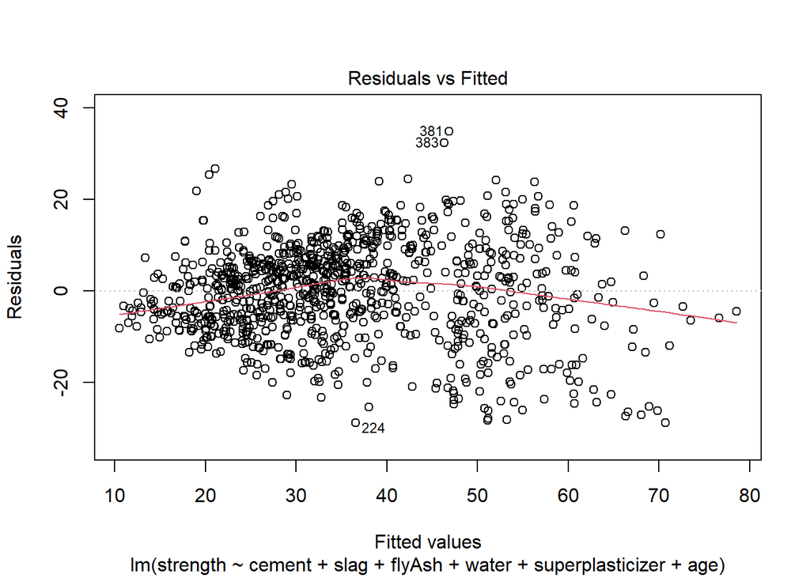

```r
mod.reg.6 <- lm(strength~ cement + slag + flyAsh + water + superplasticizer + age)
plot(mod.reg.6, which = 1)
```

The Residuals vs Fits plot for the model shows decent Linearity. You can see that the data consistently bounces around the line (e = Residuals = 0). The slope for the line of best fit, on average, is very close to 0, and doesn’t show a strong pattern. This plot also shows a fairly Constant Variance. We can draw equidistant lines from the line (e = Residuals = 0) encapsulating the points evenly.

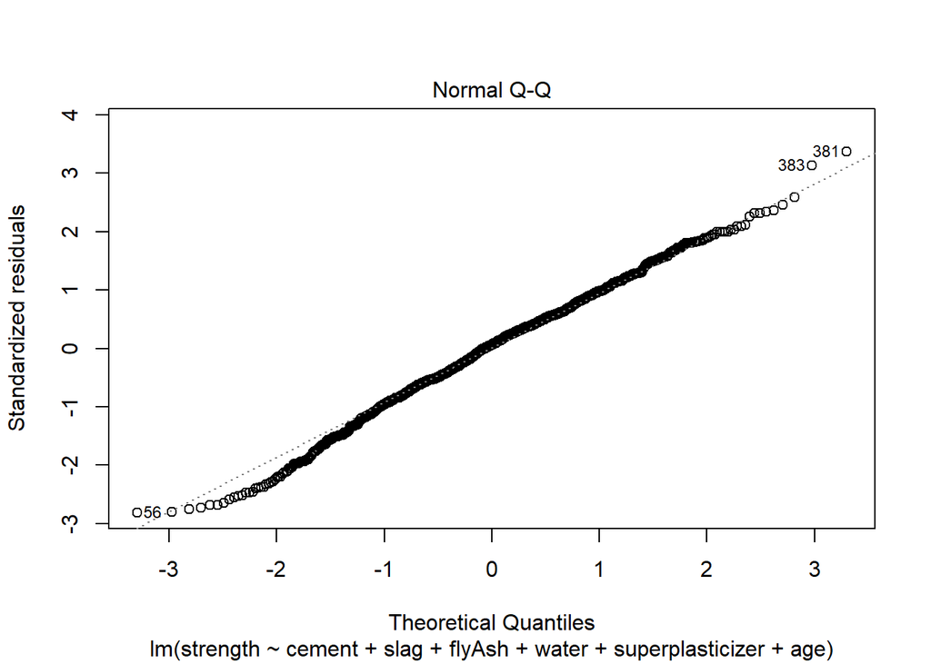

```r
plot(mod.reg.6, which = 2)
```

The Normal Q-Q plot shows decent Normality. It has room for improvement. There’s a slight skew. Let’s see what the shapiro.test has to say about the Normality of the model.

```r
test<-resid(mod.reg.6)
shapiro.test(test)
```

```
##
##  Shapiro-Wilk normality test
##
## data:  test
## W = 0.9957, p-value = 0.005534
```

$$H_0$$
: The vector is normal. vs
$$H_A$$
: The vector is not normal.

The vector that we passed into the test was the residuals of the model. Since the test determined the residuals do not follow a normal distribution, this model violates Normality.

Let’s see if adding 1 interaction term can improve Normality. I’m not going to investigate further than 1 term, for the sake of simplicity.

```r
mod.reg.6.interaction <- lm(strength~ cement + slag + flyAsh + water + superplasticizer + age + water*superplasticizer)
anova(mod.reg.6, mod.reg.6.interaction)
```

```
## Analysis of Variance Table
##
## Model 1: strength ~ cement + slag + flyAsh + water + superplasticizer +
##     age
## Model 2: strength ~ cement + slag + flyAsh + water + superplasticizer +
##     age + water * superplasticizer
##   Res.Df    RSS Df Sum of Sq      F    Pr(>F)
## 1   1022 110179
## 2   1021 107091  1    3088.5 29.445 7.183e-08 ***
## ---
## Signif. codes:  0 '***' 0.001 '**' 0.01 '*' 0.05 '.' 0.1 ' ' 1
```

$$H_0$$
: $\beta_{45}$ = 0 vs
$$H_A$$
: $\beta_{45}$ 0

This means that $\beta_{45}$ 0, and that the interaction term `water*superplasticizer` can be added to the model.

I manually went through every possible combination (5 + 4 + 3 + 2 + 1) of possible interaction terms to determine which interaction term would pass this test, and also improve normality. The following Shapiro-Wilk test shows that`water*superplasticizer` improved normality by a lot.

```r
test<-resid(mod.reg.6.interaction)
shapiro.test(test)
```

```
##
##  Shapiro-Wilk normality test
##
## data:  test
## W = 0.99674, p-value = 0.03228
```

$$H_0$$
: The vector is normal. vs
$$H_A$$
: The vector is not normal.

This means our model still violates normality. We’re getting better, but still not passing the most conventional alpha value 0.05.

Let’s try some transformations to improve the Normality of the model.

```r
trans <- powerTransform(cbind(X540.0, X0.0, X0.0.1, X162.0, X2.5, X28) ~ 1, Concrete_Data)
summary(trans)
```

```
## bcPower Transformations to Multinormality
##        Est Power Rounded Pwr Wald Lwr Bnd Wald Upr Bnd
## X540.0    0.1994        0.33       0.0459       0.3529
## X0.0      0.0440        0.04       0.0287       0.0592
## X0.0.1   -0.0406       -0.04      -0.0559      -0.0253
## X162.0    0.8624        1.00       0.4934       1.2315
## X2.5      0.1382        0.14       0.1193       0.1571
## X28       0.0562        0.06       0.0106       0.1018
##
## Likelihood ratio test that transformation parameters are equal to 0
##  (all log transformations)
##                                      LRT df       pval
## LR test, lambda = (0 0 0 0 0 0) 307.6687  6 < 2.22e-16
##
## Likelihood ratio test that no transformations are needed
##                                      LRT df       pval
## LR test, lambda = (1 1 1 1 1 1) 25321.37  6 < 2.22e-16
```

The powerTransform function gives us $\lambda$ for multiple boxCox transformations. It’s a standard to round $\lambda$ to the nearest 0.5.

Let’s apply all of the $\lambda's$ to our data, and then take a boxCox transformation to our response.

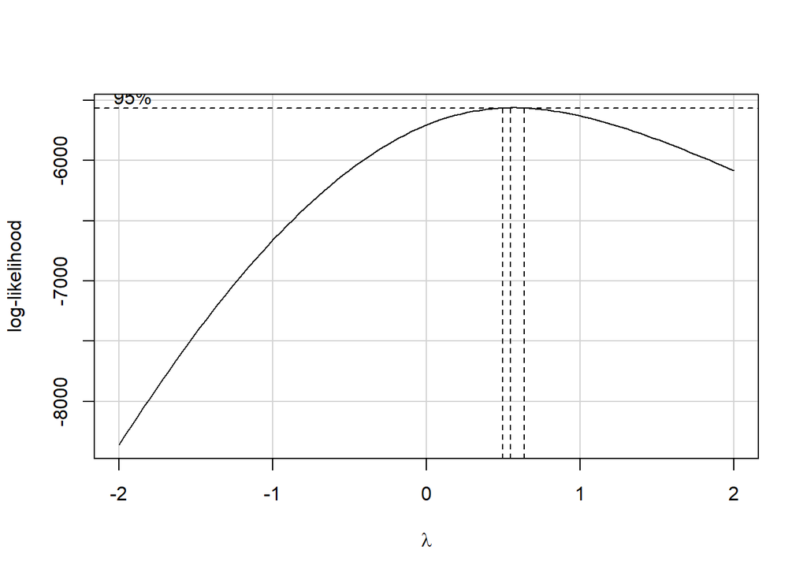

```r
cement.t <- (((cement**0.5) - 1 )/0.5)
slag.t <- log(slag)
flyAsh.t <- log(flyAsh)
water.t <- water
superplasticizer.t <- log(superplasticizer)
age.t <- log(age)

mod.reg.6.transform <- lm(strength~ cement.t + slag.t + flyAsh.t + water.t + superplasticizer.t + age.t)


boxCox(mod.reg.6.transform)
```

The optimal $\lambda$ is the maximum of the log-likelihood function. From the plot, we can see that it’s maximized around $\lambda$ = 0.5. We’ll use this value to transform our response variable, to try to improve normality.

```r
strength.t <- ((strength**0.5) - 1 )/0.5

mod.reg.6.transform <- lm(strength.t~ cement.t + slag.t + flyAsh.t + water.t + superplasticizer.t + age.t)


test<-resid(mod.reg.6.transform)
shapiro.test(test)
```

```
##
##  Shapiro-Wilk normality test
##
## data:  test
## W = 0.9971, p-value = 0.05941
```

$$H_0$$
: The vector is normal. vs
$$H_A$$
: The vector is not normal.

Test Statistic: 0.99714

Normality has improved a lot, but it’s still being violated. For this test, it’s said in Royston (1995) to be adequate for p.value < 0.1 (see `?shapiro.test`). So let’s improve past 0.1

Let’s try removing outliers. Now is a good time to do so, because we just finished our transformations.

```r
rst <- rstudent(mod.reg.6.transform)
rst <- abs(rst)
which(rst > 3)
```

```
## 224
## 224
```

```r
Concrete_Data2 = Concrete_Data[-c(225), ]

cement.2 <- Concrete_Data2$X540.0
slag.2 <- Concrete_Data2$X0.0
flyAsh.2 <- Concrete_Data2$X0.0.1
water.2 <- Concrete_Data2$X162.0
superplasticizer.2 <- Concrete_Data2$X2.5
coarseAggregate.2 <- Concrete_Data2$X1040.0
fineAggregate.2 <- Concrete_Data2$X676.0
age.2 <- Concrete_Data2$X28

strength.2 <- Concrete_Data2$X79.99

cement.t.2 <- (((cement.2**0.5) - 1 )/0.5)
slag.t.2 <- log(slag.2)
flyAsh.t.2 <- log(flyAsh.2)
water.t.2 <- water.2
superplasticizer.t.2 <- log(superplasticizer.2)
age.t.2 <- log(age.2)

strength.t.2 <- ((strength.2**0.5) - 1 )/0.5

mod.reg.6.transform.outlier <- lm(strength.t.2~ cement.t.2 + slag.t.2 + flyAsh.t.2 + water.t.2 + superplasticizer.t.2 + age.t.2)

test<-resid(mod.reg.6.transform.outlier)
shapiro.test(test)
```

```
##
##  Shapiro-Wilk normality test
##
## data:  test
## W = 0.99705, p-value = 0.05507
```

$$H_0$$
: The vector is normal. vs
$$H_A$$
: The vector is not normal.

I’m going to try to add an interaction term, but this time, with the transformed predictors. Like I did earlier, I’m going to manually iterate through possible combinations until I get an optimal interaction term.

```r
mod.reg.6.transform.interaction <- lm(strength.t~ cement.t + slag.t + flyAsh.t + water.t + superplasticizer.t + age.t + flyAsh.t*age.t)

anova(mod.reg.6.transform, mod.reg.6.transform.interaction)
```

```
## Analysis of Variance Table
##
## Model 1: strength.t ~ cement.t + slag.t + flyAsh.t + water.t + superplasticizer.t +
##     age.t
## Model 2: strength.t ~ cement.t + slag.t + flyAsh.t + water.t + superplasticizer.t +
##     age.t + flyAsh.t * age.t
##   Res.Df    RSS Df Sum of Sq      F   Pr(>F)
## 1   1022 1581.9
## 2   1021 1553.8  1    28.079 18.451 1.91e-05 ***
## ---
## Signif. codes:  0 '***' 0.001 '**' 0.01 '*' 0.05 '.' 0.1 ' ' 1
```

$$H_0$$
: $\beta_{38}$ = 0 vs
$$H_A$$
: $\beta_{38}$ 0

```r
test<-resid(mod.reg.6.transform.interaction)
shapiro.test(test)
```

```
##
##  Shapiro-Wilk normality test
##
## data:  test
## W = 0.99759, p-value = 0.1345
```

$$H_0$$
: The vector is normal. vs
$$H_A$$
: The vector is not normal.

Conclusion: This model is normal!

Let’s see if the other aspects of LINE are still respected.

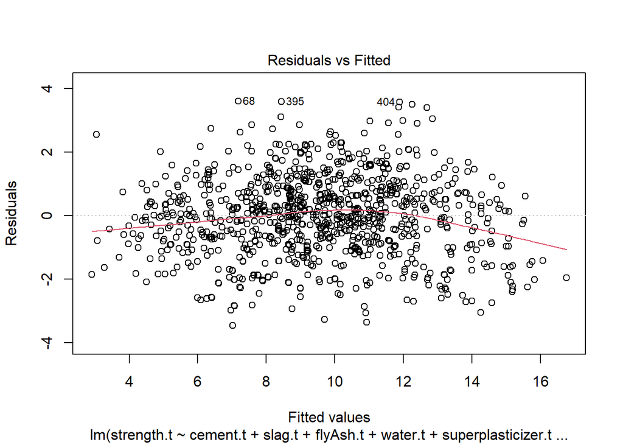

```r
plot(mod.reg.6.transform.interaction, which = 1)
```

The Residuals vs Fits plot for the model shows decent Linearity. You can see that the data consistently bounces around the line (e = Residuals = 0). The slope for the line of best fit, on average, is very close to 0, and doesn’t show a strong pattern. This plot also shows a fairly Constant Variance. We can draw equidistant lines from the line (e = Residuals = 0) encapsulating the points evenly.

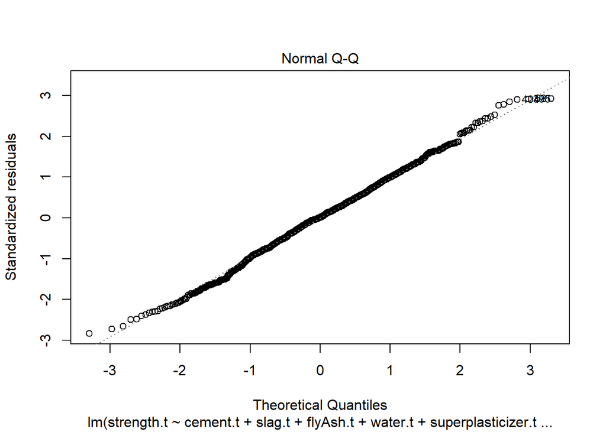

```r
plot(mod.reg.6.transform.interaction, which = 2)
```

The Normal Q-Q plot shows fantastic normality.

```r
mod.final <- mod.reg.6.transform.interaction
summary(mod.final)
```

```
##
## Call:
## lm(formula = strength.t ~ cement.t + slag.t + flyAsh.t + water.t +
##     superplasticizer.t + age.t + flyAsh.t * age.t)
##
## Residuals:
##     Min      1Q  Median      3Q     Max
## -3.4602 -0.8152  0.0131  0.7916  3.6002
##
## Coefficients:
##                     Estimate Std. Error t value Pr(>|t|)
## (Intercept)         1.987194   0.479666   4.143 3.71e-05 ***
## cement.t            0.259679   0.007250  35.817  < 2e-16 ***
## slag.t              0.123904   0.006395  19.375  < 2e-16 ***
## flyAsh.t           -0.057473   0.017680  -3.251  0.00119 **
## water.t            -0.028171   0.002264 -12.440  < 2e-16 ***
## superplasticizer.t  0.104384   0.012021   8.683  < 2e-16 ***
## age.t               1.627021   0.040104  40.570  < 2e-16 ***
## flyAsh.t:age.t      0.021475   0.005000   4.295 1.91e-05 ***
## ---
## Signif. codes:  0 '***' 0.001 '**' 0.01 '*' 0.05 '.' 0.1 ' ' 1
##
## Residual standard error: 1.234 on 1021 degrees of freedom
## Multiple R-squared:  0.8193, Adjusted R-squared:  0.818
## F-statistic: 661.2 on 7 and 1021 DF,  p-value: < 2.2e-16
```

Above is the summary.

#FOLLOWING IS JUST MESSING AROUND

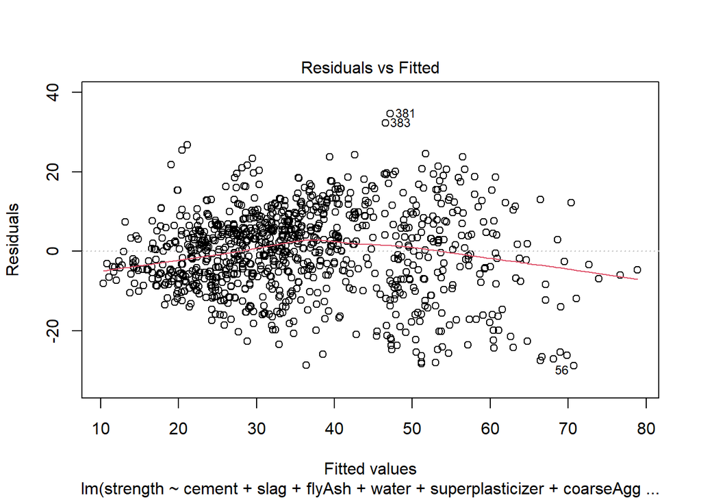

```r
mod.reg.7 <- lm(strength~ cement + slag + flyAsh + water + superplasticizer + coarseAggregate + age)
plot(mod.reg.7, which = 1)
```

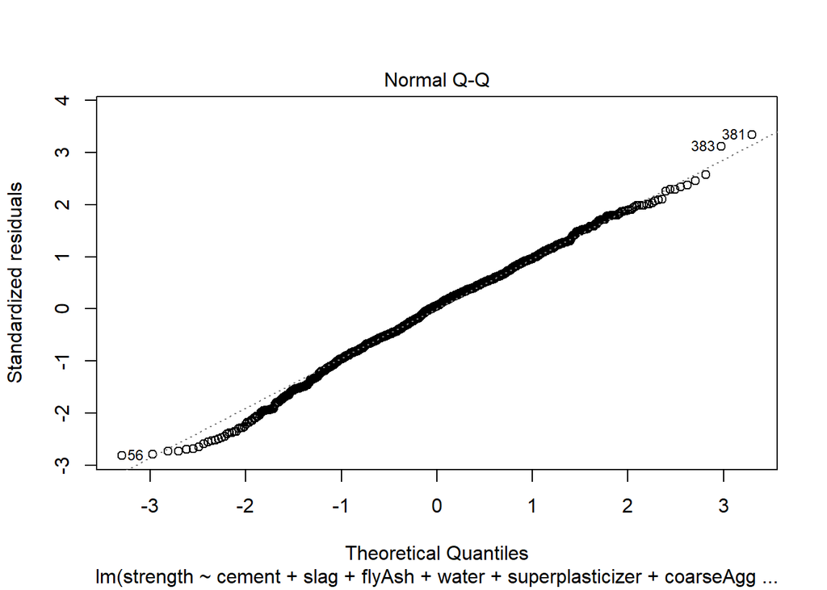

```r
plot(mod.reg.7, which = 2)
```

```r
test<-resid(mod.reg.7)
shapiro.test(test)
```

```
##
##  Shapiro-Wilk normality test
##
## data:  test
## W = 0.99565, p-value = 0.00517
```

```r
test<-resid(mod.full)
shapiro.test(test)
```

```
##
##  Shapiro-Wilk normality test
##
## data:  test
## W = 0.99517, p-value = 0.002343
```